← Volver al ensayo · Cuaderno de «¿Vive más quien tarda más en nacer?» · Descargar .ipynb

# Longevidad vs. gestación en mamíferos

### Limpieza de datos, visualización y regresión · Alejandro Vázquez · 2026

**Fuente:** AnAge — The Animal Ageing and Longevity Database (HAGR) de Magalhães & Costa (2009), *J. Evol. Biol.* 22(8):1770-1774 · https://genomics.senescence.info/species/

**Objetivo:** limpiar el dataset de AnAge, explorar relaciones entre rasgos de historia de vida y modelar la relación **gestación → longevidad**.

> **v3 (2026-10-09):** añade las secciones 12–16 (robustez, filogenia, excepciones, calidad del dato, la madurez sexual). Este cuaderno acompaña al ensayo publicado en https://alex-vazquez73.github.io/longevidad-gestacion/ — cada cifra del ensayo remite a una sección de aquí.

> El archivo `anage_data.txt` (TSV) debe estar en la misma carpeta que este notebook.

## 1 · Configuración

```python
import pandas as pd
import numpy as np
import matplotlib.pyplot as plt
import matplotlib as mpl
import seaborn as sns
import statsmodels.formula.api as smf
from scipy import stats

# Paleta del curso (Power BI oficial)
NEGRO    = "#201F1E"
GRIS     = "#3B3A39"
AMARILLO = "#F4D249"
AMA_OSC  = "#E3A810"
FONDO    = "#FAF9F8"

sns.set_theme(style="whitegrid", rc={
    "axes.facecolor": FONDO, "figure.facecolor": "white",
    "axes.edgecolor": GRIS, "grid.color": "#E8E6E3",
    "axes.labelcolor": NEGRO, "text.color": NEGRO,
    "xtick.color": GRIS, "ytick.color": GRIS, "font.family": "DejaVu Sans",
})
pd.set_option("display.max_columns", 40)
```

## 2 · Carga e inspección

```python
df = pd.read_csv("anage_data.txt", sep="\t", encoding="latin-1")
df.columns = [col.strip() for col in df.columns]   # limpiar espacios de las cabeceras
print(f"Dimensiones: {df.shape[0]} filas × {df.shape[1]} columnas")
df["Class"].value_counts().head(6)
```

```
Dimensiones: 4645 filas × 31 columnas
```

```
Class
Aves              1513
Mammalia          1349
Teleostei          806
Reptilia           547
Amphibia           181
Chondrichthyes     117
Name: count, dtype: int64
```

## 3 · Limpieza de datos

1. Filtrar a **mamíferos** (en aves/reptiles el campo mezcla gestación con incubación).
2. Seleccionar las **columnas de interés** y renombrarlas a español.
3. Convertir las columnas numéricas a número (los faltantes pasan a `NaN`).
4. Diagnosticar faltantes y descartar filas sin gestación o sin longevidad.
5. Revisar valores imposibles y duplicados.

```python
# 3.1 Filtrar a mamíferos
mam = df[df["Class"] == "Mammalia"].copy()
print(f"Mamíferos: {len(mam)} especies")
```

```
Mamíferos: 1349 especies
```

```python
# 3.2 Seleccionar columnas de interés y renombrar a español
columnas_finales = ["Order", "Common name", "Genus", "Species",
                    "Gestation/Incubation (days)", "Maximum longevity (yrs)",
                    "Adult weight (g)", "Weaning (days)", "Litter/Clutch size",
                    "Female maturity (days)", "Litters/Clutches per year",
                    "Specimen origin", "Sample size"]

renombrar = {
    "Order": "orden",
    "Common name": "nombre_comun",
    "Genus": "genero",
    "Species": "especie",
    "Gestation/Incubation (days)": "gestacion_dias",
    "Maximum longevity (yrs)": "longevidad_anios",
    "Adult weight (g)": "masa_g",
    "Weaning (days)": "destete_dias",
    "Litter/Clutch size": "camada",
    "Female maturity (days)": "madurez_dias",
    "Litters/Clutches per year": "partos_anio",
    "Specimen origin": "origen",
    "Sample size": "tam_muestra",
}

mam = mam[columnas_finales].rename(columns=renombrar)
mam["nombre_cientifico"] = mam["genero"].astype(str) + " " + mam["especie"].astype(str)
mam.head(3)
```

|  | orden | nombre_comun | genero | especie | gestacion_dias | longevidad_anios | masa_g | destete_dias | camada | madurez_dias | partos_anio | origen | tam_muestra | nombre_cientifico |
| --- | --- | --- | --- | --- | --- | --- | --- | --- | --- | --- | --- | --- | --- | --- |
| 1874 | Afrosoricida | Lesser hedgehog tenrec | Echinops | telfairi | 55.0 | 19.0 | 180.0 | 29.0 | 6.0 | 365.0 | 1.0 | captivity | medium | Echinops telfairi |
| 1875 | Afrosoricida | Large-eared tenrec | Geogale | aurita | 63.0 | NaN | 6.7 | 37.0 | 3.9 | NaN | 2.0 | unknown | small | Geogale aurita |
| 1876 | Afrosoricida | Streaked tenrec | Hemicentetes | semispinosus | 59.0 | 2.7 | 180.0 | 21.0 | 4.0 | 35.0 | 2.0 | captivity | small | Hemicentetes semispinosus |

```python
# 3.3 Convertir las columnas numéricas (origen y tam_muestra son categóricas, se quedan como texto)
num_cols = ["gestacion_dias", "longevidad_anios", "masa_g", "destete_dias", "camada",
            "madurez_dias", "partos_anio"]
for col in num_cols:
    mam[col] = pd.to_numeric(mam[col], errors="coerce")
mam.dtypes
```

```
orden                 object
nombre_comun          object
genero                object
especie               object
gestacion_dias       float64
longevidad_anios     float64
masa_g               float64
destete_dias         float64
camada               float64
madurez_dias         float64
partos_anio          float64
origen                object
tam_muestra           object
nombre_cientifico     object
dtype: object
```

```python
# 3.4 Diagnóstico de faltantes
pd.DataFrame({
    "n_faltantes": mam.isna().sum(),
    "%_faltantes": (mam.isna().mean() * 100).round(1),
})
```

|  | n_faltantes | %_faltantes |
| --- | --- | --- |
| orden | 0 | 0.0 |
| nombre_comun | 0 | 0.0 |
| genero | 0 | 0.0 |
| especie | 0 | 0.0 |
| gestacion_dias | 244 | 18.1 |
| longevidad_anios | 320 | 23.7 |
| masa_g | 12 | 0.9 |
| destete_dias | 581 | 43.1 |
| camada | 106 | 7.9 |
| madurez_dias | 328 | 24.3 |
| partos_anio | 527 | 39.1 |
| origen | 0 | 0.0 |
| tam_muestra | 0 | 0.0 |
| nombre_cientifico | 0 | 0.0 |

```python
# 3.5 Descartar filas sin las dos variables clave
antes = len(mam)
clean = mam.dropna(subset=["gestacion_dias", "longevidad_anios"]).copy()
print(f"Filas: {antes} -> {len(clean)} (se eliminaron {antes - len(clean)})")
```

```
Filas: 1349 -> 877 (se eliminaron 472)
```

```python
# 3.6 Valores imposibles y duplicados
clean = clean[(clean["gestacion_dias"] > 0) & (clean["longevidad_anios"] > 0)]
clean = clean.drop_duplicates(subset="nombre_cientifico").reset_index(drop=True)
print("Dataset limpio:", len(clean), "especies")
clean[num_cols].describe().round(1)
```

```
Dataset limpio: 877 especies
```

|  | gestacion_dias | longevidad_anios | masa_g | destete_dias | camada | madurez_dias | partos_anio |
| --- | --- | --- | --- | --- | --- | --- | --- |
| count | 877.0 | 877.0 | 876.0 | 592.0 | 853.0 | 785.0 | 623.0 |
| mean | 123.9 | 20.8 | 667814.6 | 149.8 | 2.4 | 706.7 | 1.6 |
| std | 107.1 | 16.3 | 6682024.6 | 167.2 | 2.0 | 783.8 | 1.3 |
| min | 10.0 | 2.1 | 2.1 | 13.0 | 1.0 | 24.0 | 0.1 |
| 25% | 34.0 | 9.8 | 171.8 | 38.0 | 1.0 | 270.0 | 1.0 |
| 50% | 85.0 | 17.9 | 2965.2 | 86.5 | 1.6 | 450.0 | 1.0 |
| 75% | 180.0 | 27.0 | 23000.0 | 195.8 | 3.1 | 842.0 | 2.0 |
| max | 670.0 | 211.0 | 136000000.0 | 1111.0 | 18.0 | 8212.0 | 10.0 |

## 4 · Scatter con seaborn: gestación vs. longevidad

Con seaborn el scatter es una sola línea (`sns.scatterplot`). Aprovechamos la columna `origen` en el parámetro `hue` para colorear por procedencia del ejemplar (silvestre / cautiverio / desconocido): los animales en cautiverio suelen registrar longevidades mayores, un **sesgo** importante a tener presente al modelar.

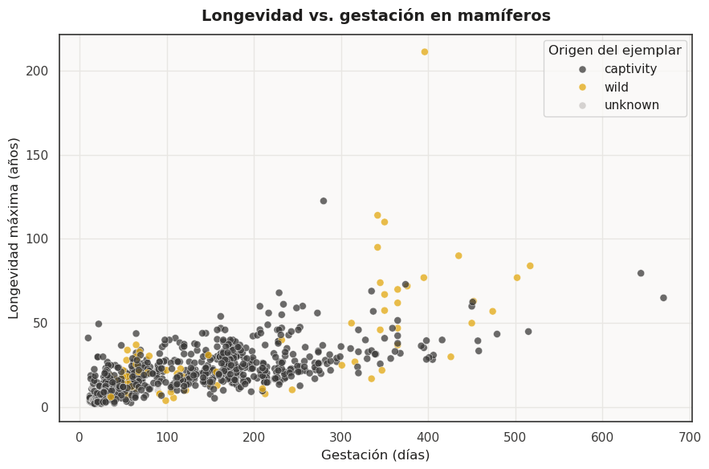

```python
pal_origen = {"wild": AMA_OSC, "captivity": GRIS, "unknown": "#C9C6C3"}

plt.figure(figsize=(9, 6))
ax = sns.scatterplot(data=clean, x="gestacion_dias", y="longevidad_anios",
                     hue="origen", palette=pal_origen, s=42, alpha=0.75,
                     edgecolor="white", linewidth=0.4)
ax.set_xlabel("Gestación (días)")
ax.set_ylabel("Longevidad máxima (años)")
ax.set_title("Longevidad vs. gestación en mamíferos", fontsize=14, fontweight="bold", color=NEGRO, pad=12)
ax.legend(title="Origen del ejemplar")
plt.tight_layout()
plt.show()
```

## 5 · Heatmap de correlaciones entre variables numéricas

Como estas variables abarcan varios órdenes de magnitud y están muy sesgadas, trabajamos con sus **logaritmos**: en escala log las relaciones alométricas son lineales y la correlación de Pearson las captura mejor. El heatmap incluye las siete variables numéricas.

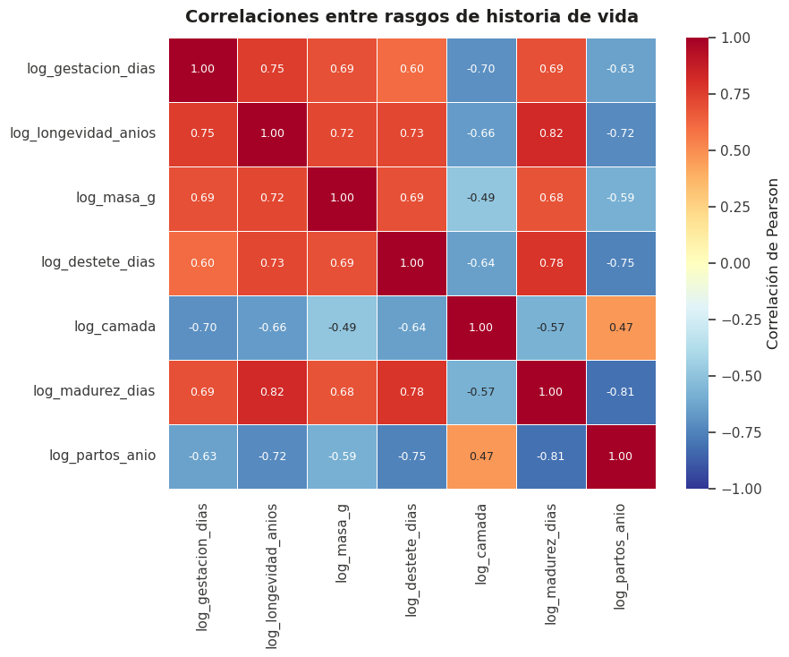

```python
# Versiones log de todas las variables numéricas (la alometría es lineal en log-log)
for col in num_cols:
    clean["log_" + col] = np.log10(clean[col])

log_vars = ["log_" + x for x in num_cols]
corr = clean[log_vars].corr()

plt.figure(figsize=(9, 7.5))
sns.heatmap(corr, annot=True, fmt=".2f", cmap="RdYlBu_r", center=0,
            vmin=-1, vmax=1, linewidths=0.5, linecolor="white",
            cbar_kws={"label": "Correlación de Pearson"}, annot_kws={"size": 9})
plt.title("Correlaciones entre rasgos de historia de vida", fontsize=14, fontweight="bold", color=NEGRO, pad=12)
plt.tight_layout()
plt.show()
```

**Cómo leerlo:** la **madurez sexual** (`log_madurez_dias`) es la que más correlaciona con la longevidad (0.82) — incluso más que la gestación —, una pista que retomaremos al mejorar el modelo. La masa corporal correlaciona con casi todo: es el motor alométrico. Y la camada y los partos/año van en **negativo** contra la longevidad: el continuo r/K en una sola imagen.

## 6 · Regresión lineal: gestación → longevidad

### ¿Qué librería conviene para profundizar?

| Librería | Para qué sirve | Inferencia (p-valores, IC) |
| --- | --- | --- |
| `scipy.stats.linregress` | Regresión bivariada rápida (pendiente, R², p) | Básica |
| **`statsmodels`** | **Modelado estadístico e inferencia** (OLS, resúmenes, IC, pruebas de hipótesis, diagnósticos) | **Completa** |
| `scikit-learn` | Predicción / *machine learning*, validación cruzada, múltiples *features* | No por defecto (sin p-valores) |
| `seaborn` (`regplot`) | **Visualizar** la regresión con banda de confianza | Solo gráfico |

**Recomendación:** usa **`statsmodels`** como base. Está pensado justo para lo que quieres — **probar hipótesis**: te da R², R² ajustado, errores estándar, p-valores, intervalos de confianza, el estadístico F y diagnósticos de residuales. `scipy` sirve para chequeos rápidos, `seaborn` para graficar y `scikit-learn` cuando el objetivo sea predecir, no explicar. (Para correlaciones parciales y pruebas tipo ANOVA muy cómodas, `pingouin` es un buen complemento.)

```python
# 6.1 Regresión lineal simple con statsmodels (API de fórmulas, estilo R)
modelo = smf.ols("longevidad_anios ~ gestacion_dias", data=clean).fit()
print(modelo.summary())
```

```
                            OLS Regression Results
==============================================================================
Dep. Variable:       longevidad_anios   R-squared:                       0.464
Model:                            OLS   Adj. R-squared:                  0.464
Method:                 Least Squares   F-statistic:                     758.0
Date:                Fri, 09 Oct 2026   Prob (F-statistic):          1.10e-120
Time:                        20:25:59   Log-Likelihood:                -3417.1
No. Observations:                 877   AIC:                             6838.
Df Residuals:                     875   BIC:                             6848.
Df Model:                           1
Covariance Type:            nonrobust
==================================================================================
                     coef    std err          t      P>|t|      [0.025      0.975]
----------------------------------------------------------------------------------
Intercept          7.9296      0.616     12.877      0.000       6.721       9.138
gestacion_dias     0.1036      0.004     27.532      0.000       0.096       0.111
==============================================================================
Omnibus:                      845.985   Durbin-Watson:                   0.988
Prob(Omnibus):                  0.000   Jarque-Bera (JB):            72038.523
Skew:                           4.129   Prob(JB):                         0.00
Kurtosis:                      46.626   Cond. No.                         250.
==============================================================================

Notes:
[1] Standard Errors assume that the covariance matrix of the errors is correctly specified.
```

```python
# R² y coeficientes a la mano
print(f"R²        = {modelo.rsquared:.3f}")
print(f"R² ajust. = {modelo.rsquared_adj:.3f}")
print(f"Pendiente = {modelo.params['gestacion_dias']:.4f} años de longevidad por día de gestación")
print(f"p-valor pendiente = {modelo.pvalues['gestacion_dias']:.2e}")
```

```
R²        = 0.464
R² ajust. = 0.464
Pendiente = 0.1036 años de longevidad por día de gestación
p-valor pendiente = 1.10e-120
```

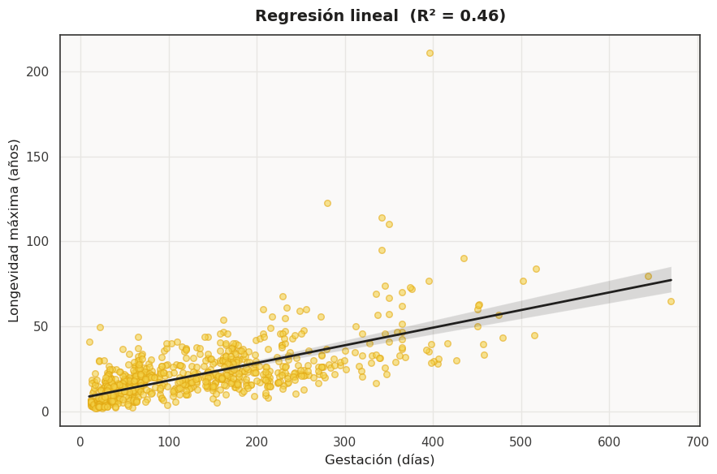

```python
# 6.2 Visualizar la regresión con seaborn (recta + banda de confianza del 95%)
plt.figure(figsize=(9, 6))
ax = sns.regplot(data=clean, x="gestacion_dias", y="longevidad_anios",
                 scatter_kws={"s": 30, "color": AMARILLO, "edgecolor": AMA_OSC, "alpha": 0.6},
                 line_kws={"color": NEGRO, "lw": 2})
ax.set_xlabel("Gestación (días)"); ax.set_ylabel("Longevidad máxima (años)")
ax.set_title(f"Regresión lineal  (R² = {modelo.rsquared:.2f})",
             fontsize=14, fontweight="bold", color=NEGRO, pad=12)
plt.tight_layout()
plt.show()
```

### 6.3 Profundizar: el modelo log-log (alométrico)

El gráfico anterior muestra que una recta no captura bien la curvatura: la relación es una **ley de potencia** $longevidad = a \cdot gestacion^{\,b}$. Tomando logaritmos se vuelve lineal, el ajuste mejora y la pendiente `b` pasa a ser el **exponente alométrico** — la cantidad con sentido biológico que querremos contrastar contra hipótesis teóricas.

```python
modelo_log = smf.ols("log_longevidad_anios ~ log_gestacion_dias", data=clean).fit()
b = modelo_log.params["log_gestacion_dias"]
print(f"Exponente alométrico b = {b:.3f}")
print(f"R² (lineal)  = {modelo.rsquared:.3f}")
print(f"R² (log-log) = {modelo_log.rsquared:.3f}   <- mejor ajuste")
```

```
Exponente alométrico b = 0.589
R² (lineal)  = 0.464
R² (log-log) = 0.567   <- mejor ajuste
```

```python
# Ejemplo de PRUEBA DE HIPÓTESIS con statsmodels:
# ¿El exponente difiere de 0.25 (valor teórico frecuente en el escalado de tiempos biológicos)?
print(modelo_log.t_test("log_gestacion_dias = 0.25"))
```

```
                             Test for Constraints
==============================================================================
                 coef    std err          t      P>|t|      [0.025      0.975]
------------------------------------------------------------------------------
c0             0.5889      0.017     19.473      0.000       0.555       0.623
==============================================================================
```

**Cómo seguir comprobando hipótesis con esta base** (ideas para practicar):

- **Confusión por tamaño corporal:** regresión múltiple `log_longevidad_anios ~ log_gestacion_dias + log_masa_g`. ¿Sigue siendo significativa la gestación al controlar por masa? (correlación parcial).
- **Efecto del cautiverio:** añade `origen` como categórica (`C(origen)`) y prueba si cambia el intercepto entre silvestres y cautivos.
- **Robustez:** filtra por `origen == "wild"` o por `tam_muestra` y verifica si los coeficientes se mantienen.
- **Comparar grupos:** prueba si el exponente difiere entre órdenes (`C(orden)`) o vía ANOVA.

Todo esto sale directo de `statsmodels` con la misma API de fórmulas.

## 7 · Regresión múltiple: ¿qué combinación predice mejor la longevidad?

En el heatmap, la longevidad (en log) correlaciona fuerte con gestación (0.75), destete (0.73) y masa (0.72), y en negativo con camada (−0.66). Tentador sumarlas todas — pero hay **tres trampas**:

1. **Multicolinealidad:** los predictores están correlacionados entre sí (a todos los empuja el tamaño corporal), así que sus R² **no se suman**.
2. **Comparación justa:** cada predictor tiene distinto número de faltantes; para comparar modelos hay que fijar la **misma muestra** (complete-case), si no el R²/AIC no son comparables.
3. **Penalizar complejidad:** más variables siempre suben el R². Usamos **R² ajustada, AIC y BIC**, que castigan parámetros de más.

```python
from statsmodels.stats.anova import anova_lm
from statsmodels.stats.outliers_influence import variance_inflation_factor

# Muestra común: mismas filas para todos los modelos -> comparación justa
base = ["log_gestacion_dias", "log_longevidad_anios", "log_masa_g", "log_camada"]
S = clean.dropna(subset=base).copy()
print(f"Muestra común: {len(S)} especies\n")

modelos = {
    "gest":                    "log_longevidad_anios ~ log_gestacion_dias",
    "masa":                    "log_longevidad_anios ~ log_masa_g",
    "camada":                  "log_longevidad_anios ~ log_camada",
    "gest+masa":               "log_longevidad_anios ~ log_gestacion_dias + log_masa_g",
    "gest+masa+camada":        "log_longevidad_anios ~ log_gestacion_dias + log_masa_g + log_camada",
    "gest+masa+camada+origen": "log_longevidad_anios ~ log_gestacion_dias + log_masa_g + log_camada + C(origen)",
}
fits, filas = {}, []
for nombre, formula in modelos.items():
    m = smf.ols(formula, data=S).fit(); fits[nombre] = m
    filas.append({"modelo": nombre, "k": int(len(m.params) - 1),
                  "R2": m.rsquared, "R2_ajustada": m.rsquared_adj, "AIC": m.aic, "BIC": m.bic})
pd.DataFrame(filas).set_index("modelo").round(3)
```

```
Muestra común: 852 especies
```

| modelo | k | R2 | R2_ajustada | AIC | BIC |
| --- | --- | --- | --- | --- | --- |
| gest | 1 | 0.568 | 0.568 | -214.767 | -205.272 |
| masa | 1 | 0.533 | 0.532 | -147.552 | -138.057 |
| camada | 1 | 0.432 | 0.431 | 19.175 | 28.670 |
| gest+masa | 2 | 0.652 | 0.651 | -395.056 | -380.813 |
| gest+masa+camada | 3 | 0.684 | 0.683 | -477.324 | -458.334 |
| gest+masa+camada+origen | 5 | 0.690 | 0.688 | -488.909 | -460.424 |

**Lectura:** como predictor único, la **gestación gana** (R²≈0.57), seguida de masa (0.53) y camada (0.43) — coincide con las correlaciones. Al combinarlas, el R² salta a **≈0.68**: cada una aporta algo distinto. (Nota que 0.57+0.53+0.43 daría más de 1: no se suman porque comparten varianza.) Añadir `origen` apenas mejora (0.684→0.690): el sesgo de cautiverio existe, pero es pequeño una vez que se controla la biología.

```python
# El punto clave: el "efecto" de la gestación se encoge al controlar por las demás
print("Coeficiente de log_gestacion_dias:")
print(f"  gestación sola      : {fits['gest'].params['log_gestacion_dias']:.3f}")
print(f"  controlando todo    : {fits['gest+masa+camada'].params['log_gestacion_dias']:.3f}")
print("\nModelo gest+masa+camada — coeficientes (todos con p < 0.001):")
print(fits['gest+masa+camada'].params.round(3).to_string())
```

```
Coeficiente de log_gestacion_dias:
  gestación sola      : 0.590
  controlando todo    : 0.239

Modelo gest+masa+camada — coeficientes (todos con p < 0.001):
Intercept             0.523
log_gestacion_dias    0.239
log_masa_g            0.089
log_camada           -0.277
```

**El corazón de la regresión múltiple:** el coeficiente de la gestación cae de **0.59 (sola) a 0.24 (controlando masa y camada)**. Buena parte de lo que parecía "efecto de la gestación" era en realidad tamaño corporal y posición en el eje r/K. Aun así sigue siendo significativo: existe un efecto propio de la gestación sobre la longevidad.

```python
# Diagnóstico de multicolinealidad (VIF). Regla de pulgar: VIF > 5 empieza a preocupar.
X = S[["log_gestacion_dias", "log_masa_g", "log_camada"]].assign(_const=1.0)
vif = {col: variance_inflation_factor(X.values, i) for i, col in enumerate(X.columns[:-1])}
print("VIF:")
for k, v in vif.items():
    print(f"  {k:20s}: {v:.2f}")
```

```
VIF:
  log_gestacion_dias  : 2.83
  log_masa_g          : 1.92
  log_camada          : 1.93
```

Los VIF rondan 2–3 (todos < 5): hay correlación entre predictores, pero **moderada**, así que el modelo múltiple es estable y sus coeficientes son interpretables.

### ¿Vale la pena añadir el destete?

El destete correlaciona fuerte con la longevidad, pero solo lo tienen ~591 especies. Para saber si aporta de verdad, comparamos con y sin destete **sobre exactamente las mismas filas** (si no, no es una comparación válida) y aplicamos una **prueba F de modelos anidados**.

```python
S2 = clean.dropna(subset=base + ["log_destete_dias"]).copy()
m_sin = smf.ols("log_longevidad_anios ~ log_gestacion_dias + log_masa_g + log_camada", data=S2).fit()
m_con = smf.ols("log_longevidad_anios ~ log_gestacion_dias + log_masa_g + log_camada + log_destete_dias", data=S2).fit()
print(f"Muestra común con destete: {len(S2)} especies")
print(f"  sin destete : R² = {m_sin.rsquared:.3f}   AIC = {m_sin.aic:.1f}")
print(f"  con destete : R² = {m_con.rsquared:.3f}   AIC = {m_con.aic:.1f}\n")
print("Prueba F de modelos anidados (¿el destete aporta?):")
anova_lm(m_sin, m_con).round(4)
```

```
Muestra común con destete: 591 especies
  sin destete : R² = 0.728   AIC = -388.1
  con destete : R² = 0.749   AIC = -433.4

Prueba F de modelos anidados (¿el destete aporta?):
```

|  | df_resid | ssr | df_diff | ss_diff | F | Pr(>F) |
| --- | --- | --- | --- | --- | --- | --- |
| 0 | 587.0 | 17.7032 | 0.0 | NaN | NaN | NaN |
| 1 | 586.0 | 16.3400 | 1.0 | 1.3632 | 48.8879 | 0.0 |

Sobre la misma muestra, el destete sube el R² de **0.73 a 0.75**, baja el AIC y la prueba F da **p ≈ 0**: **sí aporta** información propia — pero al costo de perder ~30% de las especies.

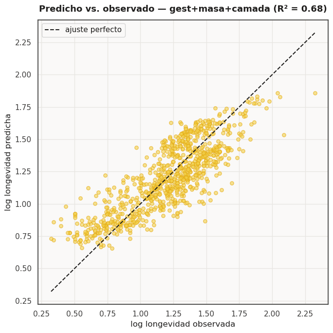

```python
# Predicho vs. observado del mejor modelo amplio (gest+masa+camada)
mejor = fits["gest+masa+camada"]
obs, pred = S["log_longevidad_anios"], mejor.fittedvalues
lims = [min(obs.min(), pred.min()), max(obs.max(), pred.max())]

plt.figure(figsize=(7, 7))
plt.scatter(obs, pred, s=28, color=AMARILLO, edgecolor=AMA_OSC, alpha=0.6)
plt.plot(lims, lims, color=NEGRO, lw=1.5, ls="--", label="ajuste perfecto")
plt.xlabel("log longevidad observada"); plt.ylabel("log longevidad predicha")
plt.title(f"Predicho vs. observado — gest+masa+camada (R² = {mejor.rsquared:.2f})",
          fontsize=13, fontweight="bold", color=NEGRO, pad=12)
plt.legend(); plt.tight_layout(); plt.show()
```

### Veredicto

- **Mejor aproximación con datos amplios** (852 especies): `gestación + masa + camada`, **R² ≈ 0.68**. El mejor equilibrio entre cobertura y poder explicativo.
- **Mejor aproximación absoluta** (591 especies): añadiendo `destete`, **R² ≈ 0.75** — si te alcanza la muestra.

Es el *trade-off* clásico **cobertura vs. precisión**.

### Otra regresión interesante: el tamaño de camada (el eje r/K)

En el heatmap, `camada` iba en contra de todo lo demás. Invertir el problema y **predecirla** revela la otra cara de la historia de vida:

```python
mc = smf.ols("log_camada ~ log_masa_g + log_gestacion_dias", data=S).fit()
print(f"log_camada ~ log_masa + log_gestacion   |   R² = {mc.rsquared:.3f}")
print(mc.params.round(3).to_string())
```

```
log_camada ~ log_masa + log_gestacion   |   R² = 0.483
Intercept             1.220
log_masa_g           -0.003
log_gestacion_dias   -0.488
```

## 8 · Cómo plantear y comprobar hipótesis

La ciencia no avanza *demostrando* que algo es cierto, sino **intentando refutarlo y fallando** (la falsabilidad de Popper). Por eso toda prueba estadística se monta al revés:

- **Hipótesis nula (H₀):** la postura escéptica del "aquí no pasa nada" → el coeficiente vale **cero**.
- **Hipótesis alternativa (H₁):** sí hay efecto → el coeficiente **no es cero**.

Supones que H₀ es cierta y preguntas: *si de verdad no hubiera efecto, ¿qué tan raros serían mis datos?* Si la respuesta es "rarísimos", rechazas H₀.

**La mecánica** (todo sale del `.summary()` de statsmodels), con el ejemplo de la gestación en el modelo `gest+masa+camada`:

1. **Estadístico t** = coeficiente / error estándar = 0.239 / 0.025 = **9.4**. Mide a cuántos errores estándar de cero está la estimación. Bajo H₀ debería rondar 0; un 9.4 está lejísimos.
2. **p-valor** ≈ 0: probabilidad de ver un resultado así de extremo *si H₀ fuera cierta*. Si es muy pequeño (< 0.05 por convención), rechazas H₀. ⚠️ *El p-valor NO es la probabilidad de que H₀ sea verdad.* Es la probabilidad de los datos suponiendo H₀. Y "no rechazar" ≠ "H₀ es cierta".
3. **Intervalo de confianza 95%** [0.189, 0.288]: el rango plausible del efecto. Como no incluye el 0, equivale a rechazar H₀ — pero además te dice *cuánto* vale.

Acechan dos errores: **Tipo I** (falso positivo, rechazar una H₀ verdadera; su tasa es α = 0.05) y **Tipo II** (falso negativo, no detectar un efecto real).

**Tres niveles de hipótesis** — el mismo marco, preguntas cada vez más ricas:

- **¿Importa la variable?** H₀: β = 0. (prueba t de cada coeficiente)
- **¿El efecto vale un valor teórico?** H₀: β = 0.25, p.ej. con `modelo.t_test("x = 0.25")`. En el modelo simple rechazamos 0.25; en el múltiple el IC [0.189, 0.288] *contiene* 0.25 → no se rechaza. La misma variable, distinta conclusión según qué controles.
- **¿Aporta un grupo de variables?** H₀: varios β = 0 a la vez → prueba **F** anidada (`anova_lm`) o la **F global** del modelo (¿explica algo el modelo entero?).

> **Causalidad:** estos son datos *observacionales*, así que medimos **asociación, no causa**. Que la gestación prediga la longevidad no prueba que la *cause*; de hecho vimos su coeficiente encogerse al controlar por otras variables — señal de confusión.

## 9 · Predecir la longevidad de un mamífero real

Despejando el modelo log-log, la longevidad estimada es una **ley de potencia**:

$$L = 10^{0.523}\cdot G^{0.239}\cdot M^{0.089}\cdot C^{-0.277}$$

Convertimos esa fórmula en una función reutilizable:

```python
# Coeficientes del modelo gest+masa+camada (sección 7)
b = fits["gest+masa+camada"].params

def predecir_longevidad(gestacion_dias, masa_g, camada):
    # Longevidad máxima estimada (años) según el modelo log-log
    log_L = (b["Intercept"]
             + b["log_gestacion_dias"] * np.log10(gestacion_dias)
             + b["log_masa_g"]         * np.log10(masa_g)
             + b["log_camada"]         * np.log10(camada))
    return 10 ** log_L

# Probar con mamíferos reales (gestación_días, masa_g, camada) y su longevidad observada
ejemplos = {
    "Perro":             ((63, 40000, 6),   27),
    "Caballo":           ((337, 300000, 1), 57),
    "Humano":            ((280, 62035, 1),  122.5),
    "Rata topo desnuda": ((70, 35, 7),      31),
    "Murciélago café":   ((55, 10, 1),      34),
}
print(f"{'animal':20s}{'predicho':>10}{'real':>8}{'factor':>8}")
for nom, ((g, m, c), real) in ejemplos.items():
    p = predecir_longevidad(g, m, c)
    print(f"{nom:20s}{p:>9.1f}a{real:>7.0f}a{real/p:>7.1f}x")
```

```
animal                predicho    real  factor
Perro                    14.1a     27a    1.9x
Caballo                  41.2a     57a    1.4x
Humano                   34.3a    122a    3.6x
Rata topo desnuda         7.4a     31a    4.2x
Murciélago café          10.7a     34a    3.2x
```

El **caballo** cae cerca (41 predicho vs. 57 real). Pero el **humano** (×3.6), la **rata topo desnuda** (×4.2) y el **murciélago** (×3.2) viven muchísimo más de lo que el modelo permite: son los residuales positivos grandes, la biología de la longevidad excepcional. El modelo capta la tendencia general (R²=0.68), no a los que rompen las reglas.

## 10 · ¿Podemos aproximar mejor? Buscar más variables

Todavía hay bastante desviación. Ya incorporamos en la limpieza (sección 3) la **madurez sexual** y los **partos/año**; aún no las hemos metido al modelo. Revisemos **cuál de todas** correlaciona más con la longevidad, sin olvidar la cobertura (una variable buenísima con pocos datos no sirve para un modelo amplio).

```python
# Todas las variables candidatas ya están en 'clean' con su versión log (sección 5)
cand = ["log_gestacion_dias", "log_masa_g", "log_camada", "log_madurez_dias", "log_partos_anio"]
resumen = pd.DataFrame({
    "corr_con_longevidad": clean[cand].corrwith(clean["log_longevidad_anios"]).round(3),
    "cobertura": clean[cand].notna().sum(),
})
resumen.sort_values("corr_con_longevidad", key=abs, ascending=False)
```

|  | corr_con_longevidad | cobertura |
| --- | --- | --- |
| log_madurez_dias | 0.821 | 785 |
| log_gestacion_dias | 0.753 | 877 |
| log_masa_g | 0.725 | 876 |
| log_partos_anio | -0.719 | 623 |
| log_camada | -0.658 | 853 |

La **madurez sexual de la hembra** correlaciona 0.82 con la longevidad — más que la gestación (0.75) — y con buena cobertura (785 especies). Es el eje "lento–rápido" de la teoría de historia de vida. La metemos al modelo y comparamos de forma justa (misma muestra).

```python
need = ["log_longevidad_anios", "log_gestacion_dias", "log_masa_g", "log_camada", "log_madurez_dias"]
Sm = clean.dropna(subset=need).copy()
print(f"Muestra común: {len(Sm)} especies\n")
for formula, etiqueta in [
    ("log_longevidad_anios ~ log_gestacion_dias + log_masa_g + log_camada", "actual (3 vars)"),
    ("log_longevidad_anios ~ log_gestacion_dias + log_masa_g + log_camada + log_madurez_dias", "+ madurez sexual")]:
    m = smf.ols(formula, data=Sm).fit()
    print(f"  {etiqueta:18s}:  R² = {m.rsquared:.3f}   R²aj = {m.rsquared_adj:.3f}   AIC = {m.aic:.1f}")

modelo_mejor = smf.ols(need[0] + " ~ " + " + ".join(need[1:]), data=Sm).fit()
print("\nCoeficientes del modelo mejorado (todos con p < 0.001):")
print(modelo_mejor.params.round(3).to_string())
```

```
Muestra común: 765 especies

  actual (3 vars)   :  R² = 0.694   R²aj = 0.693   AIC = -443.1
  + madurez sexual  :  R² = 0.783   R²aj = 0.781   AIC = -702.5

Coeficientes del modelo mejorado (todos con p < 0.001):
Intercept            -0.039
log_gestacion_dias    0.163
log_masa_g            0.043
log_camada           -0.183
log_madurez_dias      0.322
```

**El R² salta de 0.69 a 0.78.** La madurez sexual es la pieza que faltaba. Nota que el coeficiente de la gestación **se encoge** (de 0.24 a 0.16): la madurez absorbe parte del eje "desarrollo lento", porque quien gesta largo también madura tarde. (Si además añades `partos_anio`, llegas a R² ≈ 0.81, pero con menos especies.)

## 11 · ¿Cómo medir el peso real de cada variable?

Tu intuición es correcta: **la matriz de correlación no basta.** Solo muestra relaciones *de a pares* (marginales) e **ignora que las variables se solapan**, así que reparte mal el crédito cuando los predictores están correlacionados entre sí. Hay métodos mejores:

1. **Coeficientes estandarizados (β):** se estandariza todo (z-score) para que los coeficientes sean comparables entre sí. El |β| mayor = más peso *dentro del modelo*.
2. **Análisis de dominancia / valor de Shapley (LMG):** reparte el R² total de forma **justa**, promediando el aporte de cada variable sobre *todos* los órdenes posibles de entrada. Resuelve limpiamente el problema de la varianza compartida. Es el estándar de oro para "importancia relativa".

Comparemos los tres enfoques sobre el modelo mejorado:

```python
from itertools import combinations
from math import factorial

pred = ["log_gestacion_dias", "log_masa_g", "log_camada", "log_madurez_dias"]

# (a) Coeficientes estandarizados (z-score)
Z = (Sm[["log_longevidad_anios"] + pred] - Sm[["log_longevidad_anios"] + pred].mean()) \
        / Sm[["log_longevidad_anios"] + pred].std()
beta = smf.ols("log_longevidad_anios ~ " + " + ".join(pred), data=Z).fit().params.drop("Intercept")

# (b) Dominancia / Shapley: reparto justo del R²
def r2(cols):
    return smf.ols("log_longevidad_anios ~ " + " + ".join(cols), data=Sm).fit().rsquared if cols else 0.0
k = len(pred)
shap = {p: 0.0 for p in pred}
for p in pred:
    otros = [x for x in pred if x != p]
    for r in range(len(otros) + 1):
        for comb in combinations(otros, r):
            w = factorial(r) * factorial(k - r - 1) / factorial(k)
            shap[p] += w * (r2(list(comb) + [p]) - r2(list(comb)))

importancia = pd.DataFrame({
    "correlacion_simple": Sm[pred].corrwith(Sm["log_longevidad_anios"]),
    "beta_estandarizado": beta,
    "dominancia_(aporte_R2)": pd.Series(shap),
})
importancia["% del R²"] = (importancia["dominancia_(aporte_R2)"] / sum(shap.values()) * 100).round(1)
importancia.round(3).sort_values("dominancia_(aporte_R2)", ascending=False)
```

|  | correlacion_simple | beta_estandarizado | dominancia_(aporte_R2) | % del R² |
| --- | --- | --- | --- | --- |
| log_madurez_dias | 0.820 | 0.450 | 0.273 | 34.8 |
| log_gestacion_dias | 0.772 | 0.210 | 0.194 | 24.8 |
| log_masa_g | 0.734 | 0.188 | 0.175 | 22.4 |
| log_camada | -0.671 | -0.169 | 0.141 | 18.0 |

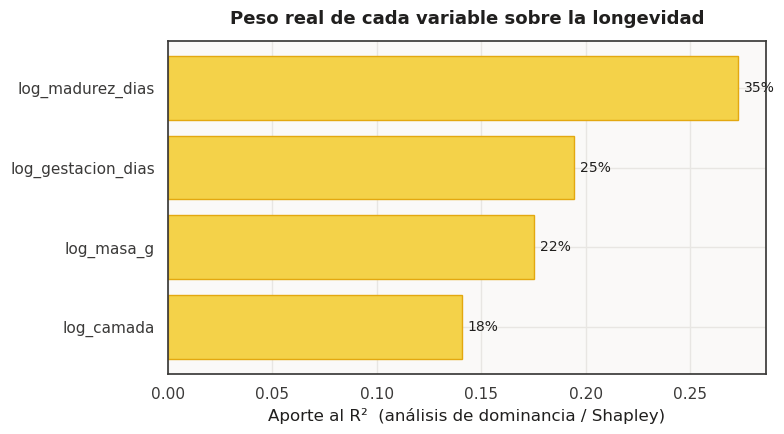

```python
# Visualizar el reparto del R² (dominancia)
orden = pd.Series(shap).sort_values()
plt.figure(figsize=(8, 4.5))
plt.barh(orden.index, orden.values, color=AMARILLO, edgecolor=AMA_OSC)
for i, v in enumerate(orden.values):
    plt.text(v + 0.003, i, f"{v/sum(shap.values())*100:.0f}%", va="center", fontsize=10, color=NEGRO)
plt.xlabel("Aporte al R²  (análisis de dominancia / Shapley)")
plt.title("Peso real de cada variable sobre la longevidad", fontsize=13, fontweight="bold", color=NEGRO, pad=12)
plt.tight_layout()
plt.show()
```

**Veredicto sobre la importancia:** los tres métodos coinciden en el orden, pero solo la dominancia reparte el R² sin doble conteo. La **madurez sexual domina (~35% del R²)**, seguida de gestación (~25%), masa (~22%) y camada (~18%). Fíjate que la matriz de correlación le daba a la masa un 0.73 — parecía muy importante — pero buena parte de ese peso lo comparte con la gestación y la madurez; al repartir justo, su aporte *único* es menor. **Esa es la diferencia entre correlación e importancia real.**

Para profundizar aún más: en R existe el paquete `relaimpo` (dominancia), y en Python puedes usar `shap` para modelos más complejos o `pingouin` para correlaciones parciales con salida limpia.

## 12 · Robustez: errores, la hipótesis nula correcta y el sesgo de atenuación

*(Sección añadida el 2026-10-09 para el ensayo.)*

Tres comprobaciones sobre el modelo log-log de la §6.3:

1. **Heterocedasticidad.** La dispersión de los residuales no es constante (prueba de Breusch-Pagan). Recalculamos los errores estándar con la corrección robusta **HC3** para ver si cambia alguna conclusión.
2. **La hipótesis nula que importa.** En la §6.3 contrastamos *b* = 0.25, pero 1/4 es el exponente de la *masa* en el escalado de tiempos biológicos, no el de un tiempo contra otro. Si gestación y longevidad escalaran ambas como *M*^1/4, entre sí serían **proporcionales**: *b* = 1. Ésa es la nula con sentido biológico.
3. **Atenuación.** Cuando las dos variables tienen ruido y ninguna es «la causa», la pendiente OLS se encoge hacia cero. La pendiente de eje mayor reducido (RMA = *b*/*r*) es la referencia simétrica.

```python
from statsmodels.stats.diagnostic import het_breuschpagan
bp = het_breuschpagan(modelo_log.resid, modelo_log.model.exog)
print(f"Breusch-Pagan: LM = {bp[0]:.1f}, p = {bp[1]:.1e}   (lineal: p = {het_breuschpagan(modelo.resid, modelo.model.exog)[1]:.1e})")
rob = modelo_log.get_robustcov_results(cov_type="HC3")
print(f"Pendiente log-log = {modelo_log.params['log_gestacion_dias']:.3f}")
print(f"  EE clásico = {modelo_log.bse['log_gestacion_dias']:.4f}   EE robusto HC3 = {rob.bse[1]:.4f}")
print(f"  IC95% robusto = [{rob.conf_int()[1][0]:.3f}, {rob.conf_int()[1][1]:.3f}]")
rmse = np.sqrt(np.mean(modelo_log.resid**2))
print(f"Error típico en log10 = {rmse:.3f}  ->  factor multiplicativo ×{10**rmse:.2f}")
print(f"Duplicar la gestación multiplica la longevidad esperada por ×{2**modelo_log.params['log_gestacion_dias']:.2f}")
```

```
Breusch-Pagan: LM = 23.6, p = 1.2e-06   (lineal: p = 9.3e-08)
Pendiente log-log = 0.589
  EE clásico = 0.0174   EE robusto HC3 = 0.0190
  IC95% robusto = [0.552, 0.626]
Error típico en log10 = 0.212  ->  factor multiplicativo ×1.63
Duplicar la gestación multiplica la longevidad esperada por ×1.50
```

```python
# La nula con sentido biológico: b = 1 (los dos relojes escalan igual)
print(modelo_log.t_test("log_gestacion_dias = 1"))

# Pendiente simétrica (RMA) y los exponentes de masa de cada reloj
r = np.sqrt(modelo_log.rsquared)
print(f"r = {r:.3f}   pendiente OLS = {modelo_log.params['log_gestacion_dias']:.3f}   pendiente RMA = b/r = {modelo_log.params['log_gestacion_dias']/r:.3f}")
dM = clean.dropna(subset=["log_masa_g"])
eg = smf.ols("log_gestacion_dias ~ log_masa_g", dM).fit().params["log_masa_g"]
eL = smf.ols("log_longevidad_anios ~ log_masa_g", dM).fit().params["log_masa_g"]
print(f"gestación ∝ M^{eg:.3f}   longevidad ∝ M^{eL:.3f}   cociente = {eL/eg:.2f}")

# Correlación parcial: gestación y longevidad, descontando la masa
rg = smf.ols("log_gestacion_dias ~ log_masa_g", dM).fit().resid
rl = smf.ols("log_longevidad_anios ~ log_masa_g", dM).fit().resid
print(f"r parcial (gestación, longevidad | masa) = {np.corrcoef(rg, rl)[0,1]:.3f}")
```

```
                             Test for Constraints
==============================================================================
                 coef    std err          t      P>|t|      [0.025      0.975]
------------------------------------------------------------------------------
c0             0.5889      0.017    -23.626      0.000       0.555       0.623
==============================================================================
r = 0.753   pendiente OLS = 0.589   pendiente RMA = b/r = 0.782
```

```
gestación ∝ M^0.198   longevidad ∝ M^0.163   cociente = 0.82
r parcial (gestación, longevidad | masa) = 0.507
```

**Lectura.** La heterocedasticidad existe, pero el error robusto (≈0.019) apenas se aleja del clásico (≈0.017): la conclusión no cambia. La nula *b* = 1 se rechaza con fuerza (t ≈ −24): la longevidad crece **menos que proporcionalmente** con la gestación. Pero ojo con la magnitud: la pendiente simétrica es ≈0.78, y el cociente de los exponentes de masa (0.163/0.198 ≈ 0.82) cuenta la misma historia. Parte del 0.59 es atenuación estadística; la sublinealidad real ronda 0.8.

## 13 · El árbol de la vida: placentarios, marsupiales y órdenes

*(Sección añadida el 2026-10-09.)*

Las 877 especies **no son observaciones independientes**: comparten ancestros. Un ratón y una rata se parecen porque son parientes, no porque «obedezcan» la misma ley. Sin un árbol filogenético (PGLS) no podemos corregirlo del todo, pero sí aproximarlo:

- **Marsupiales y monotremas:** su «gestación» no mide lo mismo. El canguro nace a los 33 días y termina de desarrollarse en la bolsa; el equidna pone un huevo. Los separamos.
- **Efectos fijos de orden:** comparamos especies *dentro* del mismo orden, con errores agrupados (cluster) por orden.
- **Pendiente por orden** y prueba F de que todas sean iguales.

```python
NO_PLAC = ["Diprotodontia", "Dasyuromorphia", "Didelphimorphia", "Peramelemorphia", "Monotremata"]
clean["placentario"] = ~clean["orden"].isin(NO_PLAC)
print(clean.loc[~clean.placentario, "orden"].value_counts().to_string(), "\n")
plac = clean[clean.placentario]
for etiqueta, datos in [("todos (877)", clean), (f"placentarios ({len(plac)})", plac)]:
    f = smf.ols("log_longevidad_anios ~ log_gestacion_dias", datos).fit()
    print(f"{etiqueta:20s} b = {f.params['log_gestacion_dias']:.3f}   R² = {f.rsquared:.3f}")
res_np = clean.loc[~clean.placentario, "log_longevidad_anios"] - modelo_log.predict(clean[~clean.placentario])
print(f"Marsupiales y monotremas viven, en promedio, ×{10**res_np.mean():.2f} lo que predice su gestación")
```

```
orden
Diprotodontia      41
Dasyuromorphia     22
Didelphimorphia    10
Peramelemorphia     8
Monotremata         3

todos (877)          b = 0.589   R² = 0.567
placentarios (793)   b = 0.651   R² = 0.613
Marsupiales y monotremas viven, en promedio, ×1.36 lo que predice su gestación
```

```python
grandes = clean["orden"].value_counts()
grandes = grandes[grandes >= 15].index
CB = clean[clean["orden"].isin(grandes)].copy()
grupos = pd.factorize(CB["orden"])[0]

pooled = smf.ols("log_longevidad_anios ~ log_gestacion_dias", CB).fit()
fe     = smf.ols("log_longevidad_anios ~ log_gestacion_dias + C(orden)", CB).fit(cov_type="cluster", cov_kwds={"groups": grupos})
CBm = CB.dropna(subset=["log_masa_g"]); gm = pd.factorize(CBm["orden"])[0]
fe_m   = smf.ols("log_longevidad_anios ~ log_gestacion_dias + log_masa_g + C(orden)", CBm).fit(cov_type="cluster", cov_kwds={"groups": gm})
print(f"{len(grandes)} órdenes con ≥15 especies, N = {len(CB)}")
print(f"  sin efectos fijos        : b = {pooled.params['log_gestacion_dias']:.3f}")
print(f"  dentro de cada orden     : b = {fe.params['log_gestacion_dias']:.3f}  (EE cluster {fe.bse['log_gestacion_dias']:.3f})")
print(f"  dentro de orden + masa   : b = {fe_m.params['log_gestacion_dias']:.3f}  (EE cluster {fe_m.bse['log_gestacion_dias']:.3f}, p = {fe_m.pvalues['log_gestacion_dias']:.1e})")

# Pendiente dentro de cada orden
filas = []
for o in grandes:
    s = clean[clean["orden"] == o]
    f = smf.ols("log_longevidad_anios ~ log_gestacion_dias", s).fit()
    filas.append({"orden": o, "n": len(s), "pendiente": f.params["log_gestacion_dias"],
                  "EE": f.bse["log_gestacion_dias"], "p": f.pvalues["log_gestacion_dias"], "R2": f.rsquared})
pd.DataFrame(filas).set_index("orden").round(3)
```

```
10 órdenes con ≥15 especies, N = 803
  sin efectos fijos        : b = 0.596
  dentro de cada orden     : b = 0.508  (EE cluster 0.093)
  dentro de orden + masa   : b = 0.196  (EE cluster 0.096, p = 4.2e-02)
```

| orden | n | pendiente | EE | p | R2 |
| --- | --- | --- | --- | --- | --- |
| Rodentia | 189 | 0.630 | 0.049 | 0.000 | 0.466 |
| Carnivora | 145 | 0.518 | 0.046 | 0.000 | 0.468 |
| Artiodactyla | 142 | 0.518 | 0.074 | 0.000 | 0.257 |
| Primates | 134 | 0.828 | 0.111 | 0.000 | 0.295 |
| Chiroptera | 65 | -0.024 | 0.118 | 0.836 | 0.001 |
| Diprotodontia | 41 | 0.112 | 0.198 | 0.573 | 0.008 |
| Cetacea | 35 | 1.644 | 0.592 | 0.009 | 0.189 |
| Dasyuromorphia | 22 | 0.067 | 0.191 | 0.728 | 0.006 |
| Soricomorpha | 15 | 0.883 | 0.317 | 0.015 | 0.374 |
| Perissodactyla | 15 | 0.428 | 0.306 | 0.186 | 0.130 |

```python
# ¿Son iguales las pendientes de todos los órdenes? Prueba F (modelos anidados)
fe_ols = smf.ols("log_longevidad_anios ~ log_gestacion_dias + C(orden)", CB).fit()
inter  = smf.ols("log_longevidad_anios ~ log_gestacion_dias * C(orden)", CB).fit()
anova_lm(fe_ols, inter).round(4)
```

|  | df_resid | ssr | df_diff | ss_diff | F | Pr(>F) |
| --- | --- | --- | --- | --- | --- | --- |
| 0 | 792.0 | 20.8740 | 0.0 | NaN | NaN | NaN |
| 1 | 783.0 | 19.0584 | 9.0 | 1.8156 | 8.288 | 0.0 |

```python
# Lo más estricto que permiten los datos: modelo completo con efectos fijos de orden
need = ["log_longevidad_anios", "log_gestacion_dias", "log_masa_g", "log_camada", "log_madurez_dias"]
SF = clean.dropna(subset=need)
SF = SF[SF["orden"].isin(grandes)]
full_fe = smf.ols("log_longevidad_anios ~ log_gestacion_dias + log_masa_g + log_camada + log_madurez_dias + C(orden)", SF).fit()
print(f"N = {len(SF)}   R² = {full_fe.rsquared:.3f}")
print(f"gestación: b = {full_fe.params['log_gestacion_dias']:.3f}  IC95% = {full_fe.conf_int().loc['log_gestacion_dias'].round(3).tolist()}  p = {full_fe.pvalues['log_gestacion_dias']:.4f}")
print(f"madurez  : b = {full_fe.params['log_madurez_dias']:.3f}")
```

```
N = 698   R² = 0.847
gestación: b = 0.101  IC95% = [0.03, 0.172]  p = 0.0051
madurez  : b = 0.224
```

**Lectura.** Sacar a marsupiales y monotremas *mejora* el ajuste (R² 0.57 → 0.61, *b* 0.59 → 0.65): sus residuales gigantes no eran biología de la longevidad sino una variable que en ellos mide otra cosa. Dentro de cada orden la pendiente se mantiene (≈0.51), pero al sumar la masa cae a ≈0.20 con un error agrupado grande. Y la prueba F es contundente: **las pendientes difieren entre órdenes**. En primates la gestación pesa mucho (≈0.83); en murciélagos no pesa nada (≈0, p = 0.84). La «ley» es en buena parte una regularidad *entre* ramas del árbol.

## 14 · Los que rompen la regla

*(Sección añadida el 2026-10-09.)*

Los residuales del modelo log-log, convertidos en factor (`10**residual`): cuántas veces más (o menos) vive una especie de lo que predice su gestación.

```python
clean["factor"] = 10 ** modelo_log.resid
cols = ["nombre_comun", "orden", "gestacion_dias", "longevidad_anios", "masa_g", "factor"]
print("Viven MÁS de lo que su gestación predice:")
print(clean.sort_values("factor", ascending=False)[cols].head(12).round(2).to_string(index=False))
print("\nViven MENOS:")
print(clean.sort_values("factor")[cols].head(8).round(2).to_string(index=False))
```

```
Viven MÁS de lo que su gestación predice:
                                      nombre_comun         orden  gestacion_dias  longevidad_anios      masa_g  factor
Western long-beaked echidna, or Long-nosed echidna   Monotremata            10.0              41.2      7500.0    8.89
                              Short-beaked echidna   Monotremata            22.0              49.5      3500.0    6.72
                                     Bowhead whale       Cetacea           396.0             211.0 100000000.0    5.22
                       Northern hairy-nosed wombat Diprotodontia            21.0              30.0     31000.0    4.18
                       Southern hairy-nosed wombat Diprotodontia            21.0              29.9     25500.0    4.17
                                             Human      Primates           280.0             122.5     62035.0    3.72
                              Coarse-haired wombat Diprotodontia            27.0              30.0     25500.0    3.61
                              Duck-billed platypus   Monotremata            17.0              22.6      1250.0    3.57
                                     Ground cuscus Diprotodontia            13.0              18.9      2400.0    3.50
                                       Giant panda     Carnivora            48.0              36.8    117500.0    3.15
          Common spotted cuscus, or Spotted cuscus Diprotodontia            13.0              17.0      3500.0    3.14
                                        Polar bear     Carnivora            65.0              43.8    475000.0    3.14

Viven MENOS:
              nombre_comun        orden  gestacion_dias  longevidad_anios  masa_g  factor
           Streaked tenrec Afrosoricida            59.0               2.7  180.00    0.20
      Sharp-nosed tomb bat   Chiroptera            99.0               4.0   24.43    0.22
          Greater cane rat     Rodentia           155.0               5.4 6600.00    0.23
           Star-nosed mole Soricomorpha            40.0               2.5   55.30    0.24
    Greater red musk shrew Soricomorpha            25.0               2.2   45.00    0.28
Common yellow-toothed cavy     Rodentia            54.0               3.5  337.90    0.28
  Hairy-legged vampire bat   Chiroptera           213.0               8.0   28.00    0.29
      Pallas's mastiff bat   Chiroptera           108.0               5.6   14.00    0.30
```

```python
# Factor medio por orden (media geométrica de los residuales)
por_orden = clean.groupby("orden").agg(n=("factor", "size"), factor=("factor", lambda x: 10 ** np.log10(x).mean()))
por_orden.query("n >= 10").sort_values("factor").round(2)
```

| orden | n | factor |
| --- | --- | --- |
| Soricomorpha | 15 | 0.40 |
| Dasyuromorphia | 22 | 0.75 |
| Artiodactyla | 142 | 0.77 |
| Rodentia | 189 | 0.80 |
| Chiroptera | 65 | 0.86 |
| Didelphimorphia | 10 | 0.87 |
| Perissodactyla | 15 | 0.96 |
| Lagomorpha | 12 | 1.06 |
| Primates | 134 | 1.25 |
| Cetacea | 35 | 1.32 |
| Carnivora | 145 | 1.34 |
| Diprotodontia | 41 | 1.95 |

```python
# Dos variables indicadoras: ¿cuánto explica ser murciélago o primate?
S["murcielago"] = (S["orden"] == "Chiroptera").astype(int)
S["primate"]    = (S["orden"] == "Primates").astype(int)
mb = smf.ols("log_longevidad_anios ~ log_gestacion_dias + log_masa_g + log_camada + murcielago + primate", S).fit()
print(f"R²: {fits['gest+masa+camada'].rsquared:.3f} -> {mb.rsquared:.3f}")
print(f"gestación: {fits['gest+masa+camada'].params['log_gestacion_dias']:.3f} -> {mb.params['log_gestacion_dias']:.3f}  IC95% {mb.conf_int().loc['log_gestacion_dias'].round(3).tolist()}")
print(f"ser murciélago: ×{10**mb.params['murcielago']:.2f}    ser primate: ×{10**mb.params['primate']:.2f}  (a igual gestación, masa y camada)")
```

```
R²: 0.684 -> 0.752
gestación: 0.239 -> 0.078  IC95% [0.029, 0.127]
ser murciélago: ×2.02    ser primate: ×1.91  (a igual gestación, masa y camada)
```

```python
# ¿Cuántas gestaciones caben en una vida?
clean["vidas_en_gestaciones"] = clean["longevidad_anios"] * 365.25 / clean["gestacion_dias"]
print(f"Mediana: {clean['vidas_en_gestaciones'].median():.0f} gestaciones por vida")
print(f"Humano : {clean.loc[clean.nombre_comun == 'Human', 'vidas_en_gestaciones'].iloc[0]:.0f}")
print(f"Correlación (log) entre ese cociente y la gestación: {np.corrcoef(np.log10(clean['vidas_en_gestaciones']), clean['log_gestacion_dias'])[0,1]:.2f}")
```

```
Mediana: 71 gestaciones por vida
Humano : 160
Correlación (log) entre ese cociente y la gestación: -0.62
```

**Lectura.** La lista de los que «viven de más» está dominada por tres grupos: marsupiales y monotremas (artefacto de la variable, §13), cetáceos (la ballena boreal, ×5.2) y primates (el humano, ×3.7). Los que viven de menos son musarañas, topos y algunos murciélagos tropicales. Dos indicadoras —murciélago y primate— suben el R² de 0.68 a 0.75 y **dejan a la gestación en 0.08**: casi todo lo que ella «explicaba» en el modelo amplio lo explica, mejor, saber en qué rama del árbol está la especie. Y como *b* < 1, las especies de gestación larga caben menos veces en su propia vida: la mediana es ~71 gestaciones; el humano, ~160.

## 15 · Cautiverio y calidad del dato

*(Sección añadida el 2026-10-09.)*

La longevidad de AnAge es un **récord máximo**, y el récord depende de cuántos ejemplares se han observado y dónde.

```python
print(clean["origen"].value_counts().to_string(), "\n")
mo = smf.ols("log_longevidad_anios ~ log_gestacion_dias + C(origen, Treatment('wild'))", clean).fit()
print(mo.params.round(3).to_string()); print()
for org in ["wild", "captivity"]:
    s = clean[clean["origen"] == org]
    f = smf.ols("log_longevidad_anios ~ log_gestacion_dias", s).fit()
    print(f"{org:10s} n = {len(s):3d}   b = {f.params['log_gestacion_dias']:.3f}   R² = {f.rsquared:.3f}")
print()
for q in ["tiny", "small", "medium", "large"]:
    s = clean[clean["tam_muestra"] == q]
    f = smf.ols("log_longevidad_anios ~ log_gestacion_dias", s).fit()
    print(f"muestra {q:7s} n = {len(s):3d}   b = {f.params['log_gestacion_dias']:.3f}   R² = {f.rsquared:.3f}")
```

```
origen
captivity    802
wild          70
unknown        5

Intercept                                    0.152
C(origen, Treatment('wild'))[T.captivity]   -0.064
C(origen, Treatment('wild'))[T.unknown]     -0.159
log_gestacion_dias                           0.581

wild       n =  70   b = 0.653   R² = 0.449
captivity  n = 802   b = 0.576   R² = 0.569

muestra tiny    n =  69   b = 0.427   R² = 0.366
muestra small   n = 316   b = 0.599   R² = 0.555
muestra medium  n = 341   b = 0.537   R² = 0.523
muestra large   n = 150   b = 0.443   R² = 0.417
```

**Lectura.** El 91% de los récords viene de cautiverio, así que el «sesgo de cautiverio» no se puede estimar bien: hay solo 70 especies silvestres, y entre ellas están las grandes ballenas, cuya edad se mide en el campo. Por eso, a igual gestación, el coeficiente de cautiverio sale *negativo* — no porque el zoológico acorte la vida, sino por qué especies llegan a cada grupo. La pendiente se sostiene en los dos (0.65 silvestres, 0.58 cautivas) y en todos los tamaños de muestra (0.43–0.60). La relación es robusta a la fuente del dato; su magnitud exacta, menos.

## 16 · ¿Y sin la madurez sexual? ¿No es casi lo mismo que la longevidad?

*(Sección añadida el 2026-10-09.)*

Dos preguntas sobre la variable que gana el análisis de dominancia (§11):

1. **Si la quitamos, ¿quién explica más?** Repetimos la dominancia con gestación, masa y camada, en tres muestras.
2. **¿Es circular?** La madurez es un tiempo *dentro* de la vida: nadie vive menos de lo que tarda en madurar. Si ocupara casi toda la vida, la correlación de 0.82 sería en parte aritmética. Lo comprobamos de dos formas: qué fracción de la vida ocupa la madurez, y qué pasa si en vez de la longevidad total explicamos la **vida adulta** (longevidad − madurez).

```python
def dominancia(datos, pred, y="log_longevidad_anios"):
    def r2(cols):
        return smf.ols(y + " ~ " + " + ".join(cols), data=datos).fit().rsquared if cols else 0.0
    k = len(pred); s = dict.fromkeys(pred, 0.0)
    for p_ in pred:
        otros = [x for x in pred if x != p_]
        for r in range(len(otros) + 1):
            for comb in combinations(otros, r):
                s[p_] += factorial(r) * factorial(k - r - 1) / factorial(k) * (r2(list(comb) + [p_]) - r2(list(comb)))
    tot = sum(s.values())
    return pd.DataFrame({"aporte_R2": s, "% del R²": {k_: v / tot * 100 for k_, v in s.items()}}).round(3), tot

tres = ["log_gestacion_dias", "log_masa_g", "log_camada"]
for etiqueta, datos in [("muestra amplia (852)", S),
                        ("muestra con madurez (765)", Sm),
                        ("solo placentarios", S[~S["orden"].isin(NO_PLAC)])]:
    tabla, tot = dominancia(datos, tres)
    print(f"\n{etiqueta} — N = {len(datos)}, R² total = {tot:.3f}")
    print(tabla.sort_values("aporte_R2", ascending=False).to_string())
```

```
muestra amplia (852) — N = 852, R² total = 0.684
                    aporte_R2  % del R²
log_masa_g              0.255    37.301
log_gestacion_dias      0.249    36.332
log_camada              0.180    26.367

muestra con madurez (765) — N = 765, R² total = 0.694
                    aporte_R2  % del R²
log_gestacion_dias      0.262    37.789
log_masa_g              0.247    35.517
log_camada              0.185    26.694
```

```
solo placentarios — N = 768, R² total = 0.674
                    aporte_R2  % del R²
log_gestacion_dias      0.268    39.741
log_masa_g              0.245    36.412
log_camada              0.161    23.848
```

```python
# ¿Es circular la madurez?
Sm = Sm.copy()
Sm["fraccion_madurez"] = Sm["madurez_dias"] / (Sm["longevidad_anios"] * 365.25)
print(f"La madurez ocupa, en mediana, el {Sm['fraccion_madurez'].median()*100:.1f}% de la vida máxima "
      f"(5%-95%: {Sm['fraccion_madurez'].quantile(.05)*100:.1f}% a {Sm['fraccion_madurez'].quantile(.95)*100:.1f}%)")

X4 = Sm[["log_gestacion_dias", "log_masa_g", "log_camada", "log_madurez_dias"]].assign(_const=1.0)
print("VIF con madurez:", {c_: round(variance_inflation_factor(X4.values, i), 2) for i, c_ in enumerate(X4.columns[:-1])})

# Vida adulta: lo que queda de vida después de madurar
Sm["log_vida_adulta"] = np.log10(Sm["longevidad_anios"] * 365.25 - Sm["madurez_dias"])
va = smf.ols("log_vida_adulta ~ log_gestacion_dias + log_masa_g + log_camada + log_madurez_dias", Sm).fit()
print(f"\nVariable dependiente = vida adulta   R² = {va.rsquared:.3f}")
print(va.params.round(3).to_string())
```

```
La madurez ocupa, en mediana, el 7.4% de la vida máxima (5%-95%: 2.4% a 18.2%)
```

```
VIF con madurez: {'log_gestacion_dias': np.float64(3.18), 'log_masa_g': np.float64(2.41), 'log_camada': np.float64(2.05), 'log_madurez_dias': np.float64(2.29)}

Variable dependiente = vida adulta   R² = 0.736
Intercept             2.605
log_gestacion_dias    0.175
log_masa_g            0.048
log_camada           -0.204
log_madurez_dias      0.262
```

**Lectura.** Sin la madurez, **gestación y masa quedan prácticamente empatadas**: en la muestra amplia la masa aporta 37.3% del R² y la gestación 36.3%; en la muestra con madurez y entre los placentarios, la gestación pasa adelante (37.8% y 39.7%). La camada queda tercera en todos los casos. Ninguna de las dos domina: el tamaño y la lentitud del desarrollo se reparten el crédito.

Sobre la circularidad: la madurez ocupa en mediana solo el **7%** de la vida máxima, así que no puede «fabricar» la correlación. Además, al explicar la vida *adulta*, de la que la madurez ya está restada, sigue siendo significativa y el R² apenas baja (0.78 → 0.74). La madurez no es la longevidad disfrazada. Es otra manecilla del mismo reloj, la más cercana a la que queremos leer, y por eso predice tan bien. Eso también quiere decir que no es una *explicación*: decir que «vive mucho porque madura tarde» es casi decir que vive despacio porque vive despacio.